# Altas y bajas de pensionados

A continuación, se analizan las altas y bajas de los pensionados del Régimen en estudio, específicamente, en la cantidad de ingresos de pensionados por año y por tipo de pensión (Invalidez, Vejez y Sucesión), durante un periodo que abarca desde el 2001 al 2023. Algunos pensionados no cuentan con la fecha de inicio del pago de la pensión, por lo que, no se toman en cuenta para el análisis.

En el gráfico 1, se muestra el comportamiento de la entrada de pensionados.

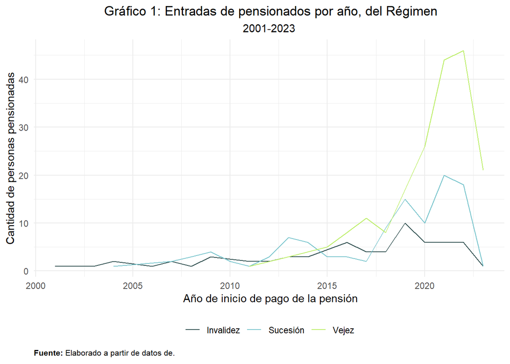

Es posible observar que para el caso de los pensionados por invalidez, las entradas entre el 2001 y el 2014 son similares, están rondando entre 1 y 3 personas. Posteriormente, se presenta un incremento a partir del 2015, alcanzando un pico de 10 nuevos pensionados por invalidez en el 2019. Sin embargo, en los último años, se experimentó una baja en la cantidad de ingresos siendo en el 2023 de una sola persona.

En cuanto a los nuevos pensionados por sucesión, se presentan registros a partir del 2004. Se puede identificar una tendencia a la alta con el mayor ingreso de pensionados por este tipo entre el 2018 y el 2022, experimentando un pico de 20 pensionados en el 2021. No obstante, al igual que la pensión anterior, se presentó un decrecimiento en las entradas ingresando solo una persona en el 2023.

Con respecto a los pensionados por vejez, no se presentó ningún registro de entrada hasta el 2011. En el periodo del 2011 al 2017, se tuvo un comportamiento creciente en los ingresos pero, bajó en el 2018 pasando de 11 nuevos pensionados a 8. En los años siguientes aumentó la cantidad de nuevos pensionados por vejez, alcanzando un valor máximo de 46 personas en el 2022. Al igual que los otros dos tipos de pensiones, para el 2023 se sufrió una reducción en los ingresos recibiendo a 21 personas.

En síntesis, se identifica que en el periodo de estudio, el mayor crecimiento de entradas de pensionados son percibidos por las pensiones por vejez, seguido de las pensiones por sucesión y por último, las de invalidez. Las tres mostraron una tendencia a la alta pero bajaron en el 2023.